[figure not shown]

Läget i Dalarna

# Introduktion

Rapporten är skapad av Samhällsanalys, Region Dalarna  
Senast uppdaterad: 2024-01-02

I Sverige har vi tillgång till mycket god statistik om både våra levnadsförhållanden och vår ekonomi. Det innebär att vi också kan följa upp bland annat den ekonomiska utvecklingen i närtid både regionalt och nationellt till exempel vad gäller sysselsättning, bostadsbyggande och företagsetableringar. De senaste årens omvälvande händelser i världen med Covid-19-pandemin, det ofattbara kriget i Ukraina, och nu kriget mellan Israel och Hamas är förödande för dem som står i händelsernas centrum, men de drabbar även oss. Dessa händelser sätter prägel på både vår ekonomi och våra levnadsförhållanden, och gör det än mer angeläget att följa den ekonomiska utvecklingen regionalt och nationellt.  
Region Dalarnas samhällsanalytiker har därför tagit fram denna rapport i syfte att ge en nulägesbild över hur läget utvecklas i Dalarna. Rapporten kommer att uppdateras regelbundet. Fokus ligger i första hand på att synliggöra det ekonomiska läget i Dalarna, vad gäller exempelvis hur arbetsmarknad och bostadsbyggande utvecklas i regionen, men många faktorer som påverkar Dalarnas ekonomi är nationella och därför startar analysen med att diskutera läget i Sverige i stort och faktorer som ramar in förutsättningarna för oss som bor och vistas i Dalarna.

# 1 Det allmänna läget i ekonomin

Det allmänna läget i en ekonomi kan beskrivas på flera sätt. I detta första avsnitt har vi valt att fokusera på tre variabler: BNP, konjunkturbarometern och inflation.

## 1.1 BNP

**Mer information om statistiken**

BNP till marknadspris från användningssidan (ENS2010). Data är säsongsrensad och på kvartalsbasis (i fasta priser). BNP är ett mått på den totala ekonomiska aktiviteten i ett land under en tidsperiod.

Genom att titta på förändring i BNP kan man få en uppfattning om hur aktiviteten i den svenska ekonomin förändras över tid. Eftersom Sveriges ekonomi, precis som de flesta andra länders, växer i normala fall, ökar BNP under en majoritet av kvartalen. Vid större kriser i samhället kan dock BNP minska avsevärt, vilket också syns i figuren nedan. Under andra kvartalet 2020 minskade aktiviteten i den svenska ekonomin med nästan 8 procent jämfört med samma kvartal året innan, vilket kan tillskrivas Corona-pandemin. Återhämtningen gick dock snabbt och redan i efteföljande kvartal så ökade BNP med nästan lika mycket som minskningen i kvartal två. Därefter följde ett par år när läget i Sveriges ekonomi kan beskrivas som gott, innan aktiviteten i ekonomin återigen minskade i kvartal ett, år 2022. Därefter har läget varit relativt skakigt och i kvartal tre 2023 var förändringen i BNP -0,3 procent.

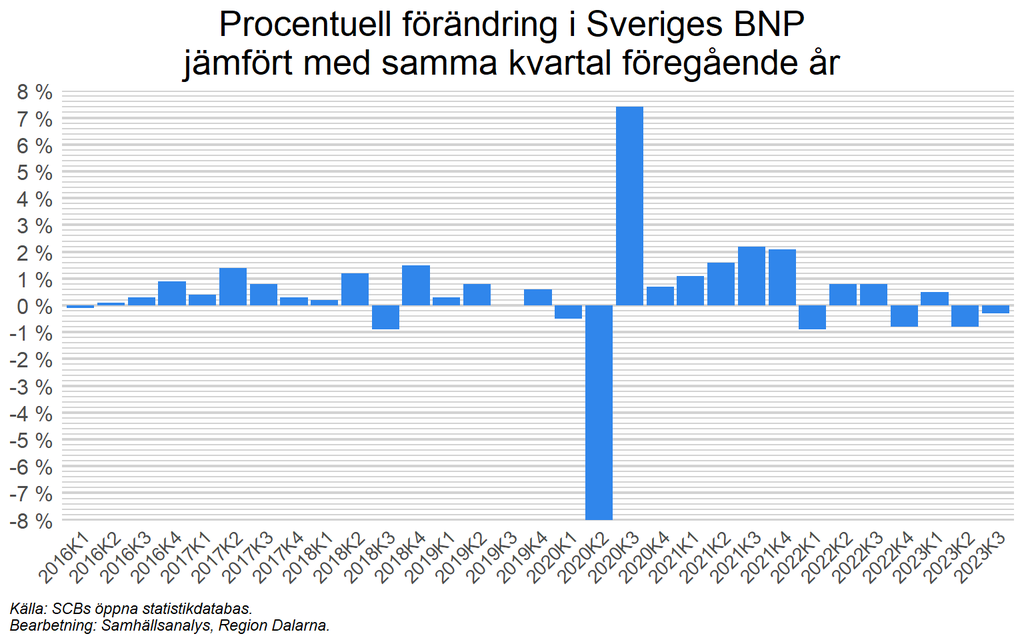

## 1.2 Konjunkturbarometern

Ett annat sätt att mäta läget i ekonomin är genom de olika enkätundersökningar som Konjunkturinstitutet regelbundet genomför, med frågor till företag och hushåll om deras uppfattning om nuläge och förväntningar på den ekonomiska utvecklingen. Svaren vägs samman i en indikator som kallas Konjunkturbarometern. Till skillnad från BNP fokuserar konjunkturbarometern inte enbart på nuläget, utan hushållen och företagen får även svara på frågor som rör framtidsutsikterna. Barometerindikatorn väger samman konfidensindikatorer från svaren i de olika enkäterna och ger varje månad en bild av konjunkturläget i Sveriges ekonomi.

**Mer information om statistiken**

Barometerindikatorn sammanfattar konfidensindikatorer för industrisektorn, tjänstesektorn, byggsektorn, detaljhandeln samt hushållen i Sverige. Indikatorerna baseras på enkätsvar från företag om bland annat deras produktion, investeringar och försäljning, men även företagens planer och förväntningar om framtiden, tillsammans med hushållens svar på enkätfrågor om deras ekonomiska situation nu och deras planer och förväntningar för framtiden. Detta sammanfattas i Konjunkturbarometern. Barometerindikatorn kan närmast jämföras med EU-kommissionens Economic Sentiment Indicator (ESI) och har ett medelvärde på 100 och en standardavvikelse på 10. Värden över 100 motsvarar en starkare ekonomi än normalt och värden över 110 en mycket starkare ekonomi än normalt. Värden under 100 respektive under 90 visar en svagare respektive mycket svagare ekonomi än normalt.

### Generellt

I december 2023 var barometerindikatorn 84,3, vilket indikerar att ekonomin i Sverige var mycket svagare än normalt. Detta kan delvis förklaras av Rysslands invasion av Ukraina och de effekter denna haft på bland annat tillgången på råvaror. Historiskt varierar barometerindikatorn med konjunkturen och större kriser i samhället, såsom finanskrisen 2008/2009 och Coronapandemin 2020/2021, syns tydligt i diagrammet.

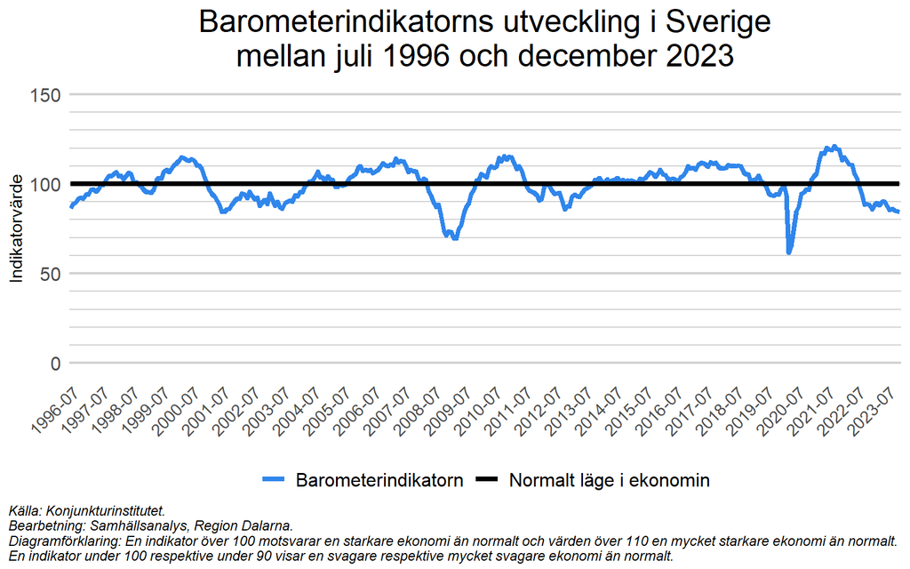

### Bransch

Hur läget i ekonomin uppfattas varierar beroende på om det är företagen eller hushållen som tillfrågas. Hushållen hade en mer pessimistisk syn än företagen på ekonomin i december 2023, med en barometerindikator på 74,5. Bland branschgrupperna i diagrammet nedan hade tillverkningsindustrin den mest positiva synen på ekonomin i december 2023, medan företag inom tjänstesektorn uppfattar den ekonomiska utvecklingen som mer negativ. Tjänstesektorn drabbades värst under pandemin (mars/april 2020), medan tillverkningsindustrin uppfattade ekonomin som starkare än normalt från slutet av 2020 fram till mitten av 2022.

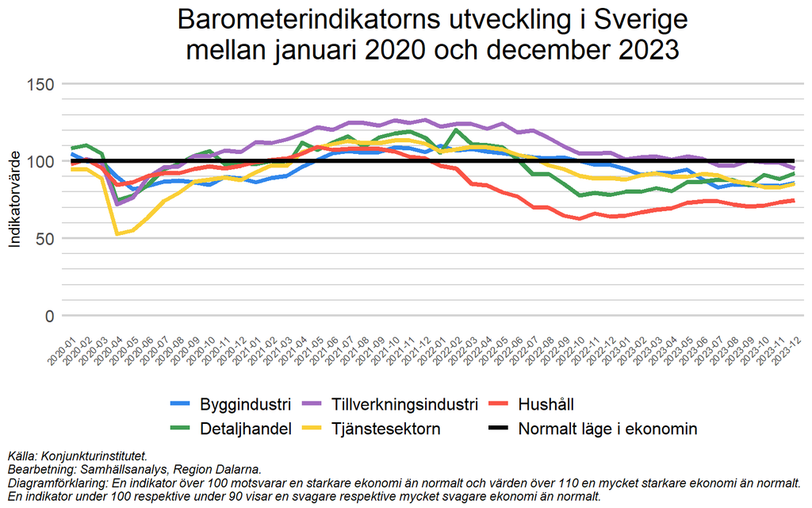

## 1.3 Inflation

Ytterligare en faktor som är viktig för ett lands ekonomi är förändringen i den allmänna prisnivån, så kallad inflation. Normalt förknippas hög inflation med problem, eftersom varor och tjänster blir dyrare. Om inte lönerna ökar i samma takt blir människor fattigare i reala termer, vilket har blivit påtagligt i Sverige det senaste året. Även låg, eller negativ, inflation kan vara skadligt för ekonomin. Exempelvis missgynnas låntagare av en sjunkande prisnivå, då deras lån ökar i värde realt. Sveriges Riksbank strävar därför efter att hålla inflationen relativt konstant över tid, runt ett uttalat inflationsmål.

**Mer information om statistiken**

Det vanligaste och mest kända sättet att mäta inflationen på i Sverige är titta på förändringen i konsumentprisindex, KPI, under senare tid har måttet utvecklats med att hålla räntenivån fast, då kallat KPIF. Anledningen är att räntan kan påverka prisnivån indirekt, framförallt boendekostnader. Konsumentprisindex med fast ränta, KPIF beräknas med samma data och på samma sätt som KPI, men utan att effekten av ändrade räntor räknas med. Indexet visar hur mycket det kostar att leva i Sverige och hur denna kostnad har utvecklats över tid. Målet för Riksbankens penningpolitik är att inflationen ska vara 2 procent. Ett viktigt skäl till den tydliga målsättningen är också att skapa trygghet och långsiktighet för företag och hushåll i deras ekonomiska beslut.

Sedan Riksbankens inflationsmål infördes 1993 har inflationen, mätt som årsförändring i KPIF, legat klart under inflationsmålet på 2 procent under långa perioder. Från sin bottennivå i april 2020 har inflationen dock ökat avsevärt och var som högst i december, 2022, då den i Sverige uppgick till 10,2 procent. Därefter har inflationstakten sjunkit och var i november, 2023, 3,6 procent. Den höga inflationstakten på senare år har ett antal olika förklaringar, däribland begränsningar i utbudet av varor när världen öppnade upp efter Corona-pandemin och Rysslands invasion av Ukraina. Läs mer på Wikipedia[^1].

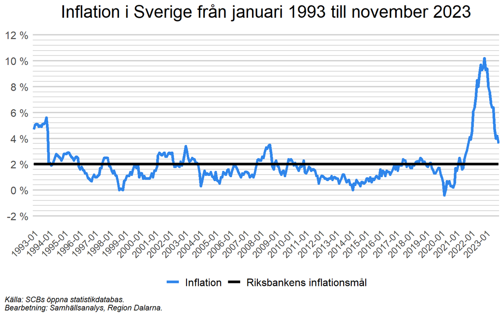

# 2 Bostadsmarknaden

2010-talet kännetecknades av en bostadsmarknad där det mesta pekade uppåt. Låg inflation och låga räntor i kombination med fördelaktiga skatteregler medförde att såväl byggandet av bostäder, som bostadspriserna ökade kraftigt. Även bostadslånen har ökat under en lång period och uppgick 2022 till ca 170 procent av hushållens disponibla inkomst, vilket är ungefär dubbelt så stor andel som under mitten av 1990-talet. Samtidigt har hushållens finansiella tillgångar ökat, vilket medfört att skulderna i relation till de finansiella tillgångarna minskat något under samma tidsperiod[^2].

## 2.1 Bostadsbyggande

**Mer information om statistiken**

Statistiken omfattar alla nybyggnadsprojekt som kräver bygglov. Bygglovsstatistik för bostäder visar antal bygglov och lägenheter. Nybyggnad av bostäder visar bostadsbyggandets omfattning och inriktning av bostadslägenheter. Data i figurerna nedan visar bygglov och nybyggnad av bostäder på kvartalsbasis.

### Bygglov

Antalet godkända bygglov för småhus varierar mellan kvartalen, men en tydlig trend är att de har börjat minska på senare tid. Sedan toppen i kvartal två, 2022, då 116 bygglov godkändes, har antalet godkända bygglov minskat och i kvartal tre, 2023, godkändes 37 bygglov. För flerbostadshus är trenden relativt likvärdig, men variationen är större från kvartal till kvartal. Under kvartal tre, 2023, godkändes bygglov för blott 16 bostadslägenheter i Dalarna.

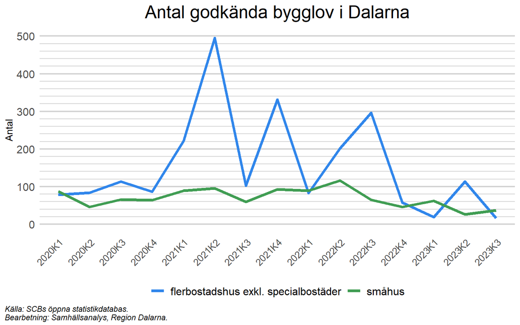

### Nybyggnation

Precis som byggloven, varierar byggandet av småhus mellan kvartalen, men en tydlig trend är att byggandet har börjat minska på senare tid. Sedan toppen i kvartal två, 2022, då 108 småhus påbörjades, har antalet minskat och i kvartal tre, 2023, påbörjades 29 småhus. För flerbostadshus är trenden relativt likvärdig, men variationen är större från kvartal till kvartal. Under kvartal tre, 2023, påbörjades byggande av 9 lägenheter i Dalarna.

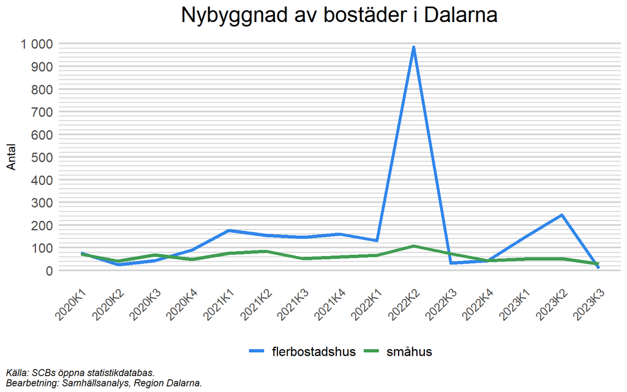

## 2.2 Bostadspriser

**Mer information om statistiken**

Noteringen om månad avser i själva verket en tremånadersperiod, där noteringen avser den sista månaden i perioden.

### Historisk jämförelse

Priserna på småhus ökade stadigt under en lång period, såväl i Dalarna som i Sverige. Efter toppen i mars, 2022, har dock det genomsnittliga priset på småhus i Dalarna minskat med ungefär 23 procent. Minskningen kan delvis förklaras av Rysslands invasion av Ukraina, vilken bland annat medfört en kraftigt ökad inflation med efterföljande räntehöjningar, något som påverkar efterfrågan på bostäder.

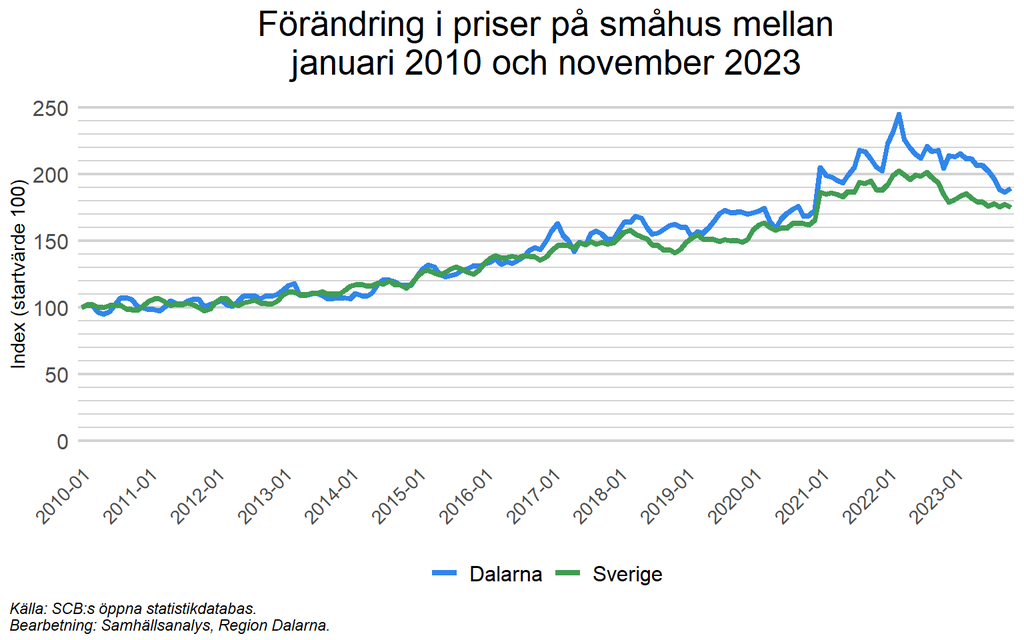

### Län

Det genomsnittliga priset på ett småhus varierar mellan Sveriges län och var i november, 2023, högst i Stockholm, där ett småhus i genomsnitt kostade 6,8 miljoner kronor. I Dalarna är priset klart lägre, ett småhus kostade i genomsnitt 2,1 miljoner kronor i länet.

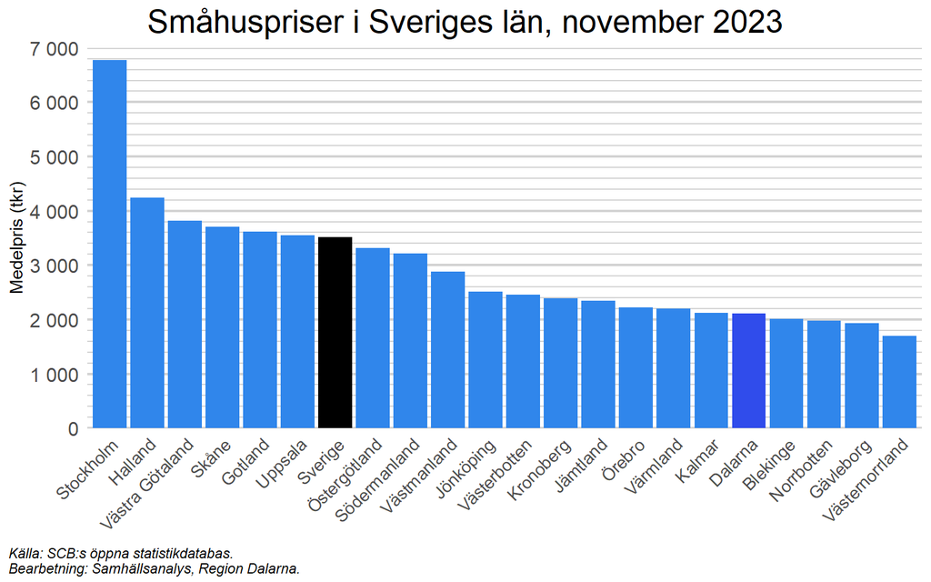

# 3 Företagandet

Läget för företagen i länet hänger naturligtvis samman med läget i ekonomin i stort. En indikator på sämre tider är att företag tvingas gå i konkurs, och en annan potentiell indikator är att färre nya företag startas.

## 3.1 Konkurser

### Konkurser per månad

Antalet personer som berörs av konkurser varierar relativt mycket från månad till månad vilket medför att det är svårt att se någon trend på månadsbasis kopplad till exempelvis Rysslands invasion av Ukraina. I november 2023 berördes 26 personer av konkurser i Dalarna, att jämföra med 19 motsvarande månad 2022. Värt att notera är även att 382 personer har berörts av konkurser i Dalarna hittills i år, vilket är klart fler än de 159 som berördes under motsvarande period föregående år.

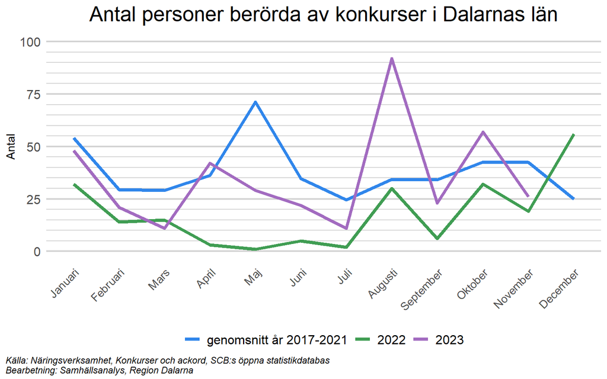

### Konkurser per bransch

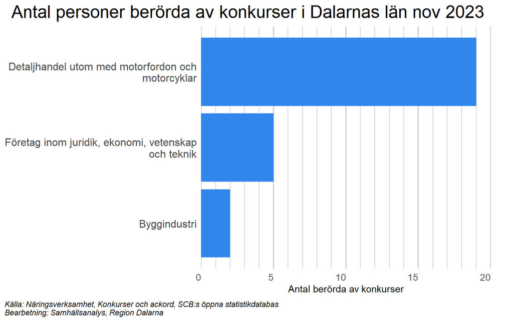

## 3.2 Avregistrerade företag

Ett potentiellt alternativ till att begära ett företag i konkurs är att istället avregistrera det. Antalet avregistrerade företag tenderar att följa ett tydligt säsongsmönster, där klart flest företag avregistreras i januari. Det är dock svårt att se någon långsiktig trend, då ungefär lika många företag avregistreras varje år. I oktober 2023 avregistrerades 71 företag i Dalarna, vilket är ungefär lika många som samma månad året innan (74).

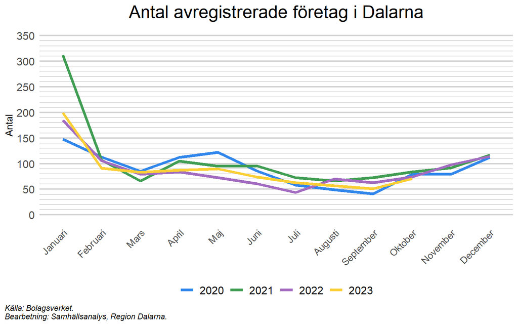

## 3.3 Nystartade företag

**Mer information om statistiken**

Statistiken beskriver mängden genuint nystartade företag. Med genuint nystartade företag menas företag som är helt nybildade eller har återupptagits efter att ha varit vilande i minst två år. Företag som nyregisteras på grund av ägarskiften, ändring av juridisk form eller annan ombildning exkluderas. Från och med 2011 är statistiken registerbaserad.

En annan indikator på läget för företagen i länet är hur många nya företag som startas. Historiskt startades väldigt många företag i samband med Corona-pandemin 2020-2021. I kvartal två 2021 startades exempelvis 506 företag, vilket är det största antalet sedan åtminstone 2011. Exakt vad detta beror på kan vara svårt att säga, men en potentiell förklaring är att individer som blev uppsagda under pandemin valde att starta egna företag. Någon större trend sedan Rysslands invasion av Ukraina märktes inte initialt för antalet nystartade företag. Under 2022 startades till och med något fler företag än genomsnittet sedan 2011. I början av 2023 märks dock en viss avmattning. I kvartal två 2023 startades 396 företag, vilket är något lägre än genomsnittet det senaste dryga decenniet.

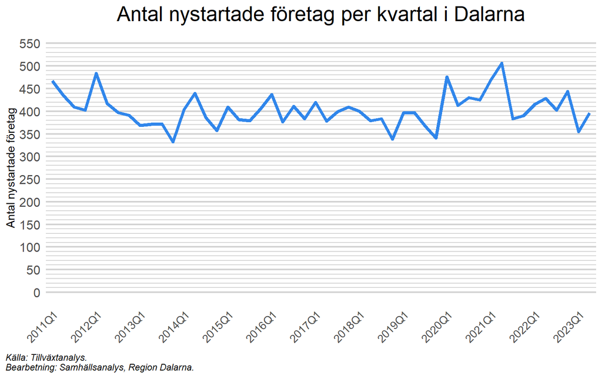

# 4 Arbetsmarknaden

Som mått på läget i Dalarna, är arbetslösheten sannolikt en relativt trögrörlig indikator. Detta eftersom företag i första läget varslar personal, för att därefter eventuellt göra större uppsägningar. De är även viktigt att notera att arbetslösheten varierar mellan olika grupper i samhället, exempelvis baserat på personers kön, utbildningsbakgrund eller huruvida de är födda i Sverige. För en fördjupad diskussion runt detta, se exempelvis rapporten “Kvinnor och män i Dalarna”[^3].

## 4.1 Arbetslöshet

**Mer information om statistiken**

Statistik över arbetslöshet och sysselsättning kan tas fram på olika sätt. Det gör att siffror som rör samma referensperiod kan skilja sig åt beroende på vilken statistikkälla som använts. I den här rapporten används BAS - befolkningens arbetsmarknadsstatus - som redovisar registerbaserad statistik över utbudet av arbetskraft i Sverige.

### Län

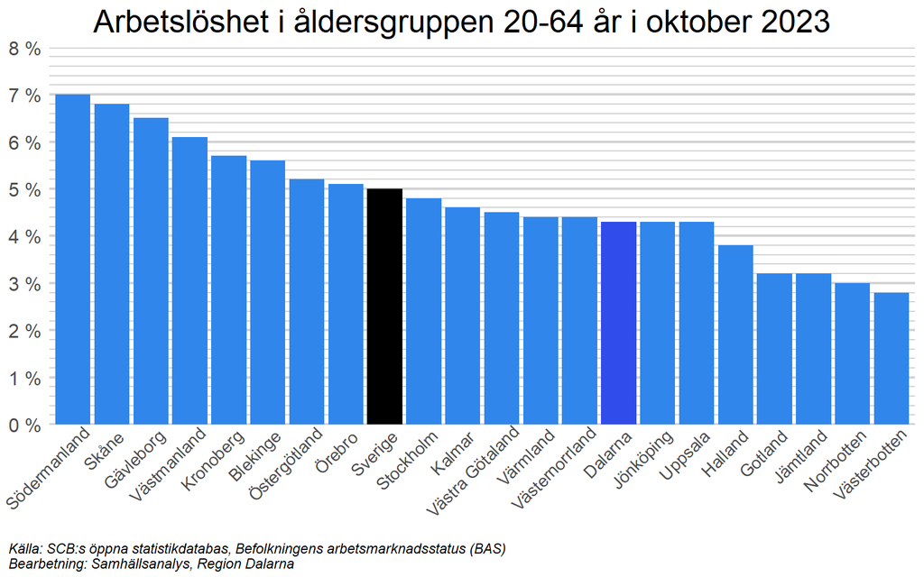

### Jämförelse över tid

Arbetslösheten, såväl i Dalarna som Sverige, varierar över tid. I samband med pandemin orsakad av Covid-19, ökade arbetslösheten och var som högst i Dalarna i februari 2021, då den uppgick till 6,5 procent. Därefter har arbetslösheten minskat och var i oktober 2023 4,3 procent i Dalarna. Värt att notera är dock att arbetslösheten för första gången på ett tag ökade något i Dalarna från juli 2023 till augusti 2023.

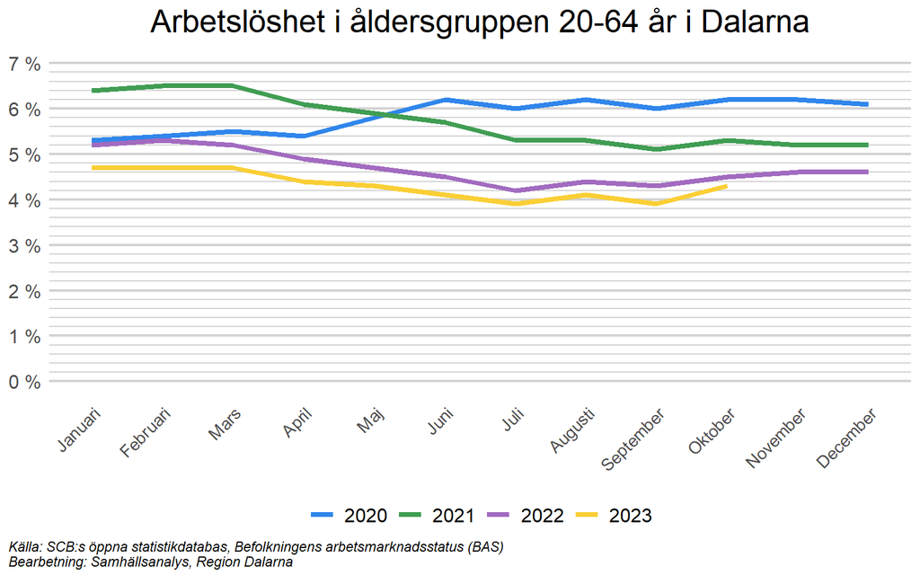

### Kommun

Arbetslösheten bland Dalarnas kommuner är låg på många håll, där en majoritet av länets kommuner hade mellan 2 och 4 procents arbetslöshet i oktober 2023. Lägst är arbetslösheten i Gagnef, med 2,1 procent. I södra delarna av länet är bilden en annan, där flera kommuner har runt 6 procents arbetslöshet. Högst är arbetslösheten i Avesta, där den uppgår till 7 procent. En tänkbar orsak till detta mönster är att de kommuner med högst arbetslöshet också är de kommuner som har högst andel utrikes födda. Den sistnämnda gruppen tenderar att hamna i arbetslöshet i högre utsträckning än inrikes födda.

[interactive chart not shown]

# 5 Hushållens ekonomi

Hushållens ekonomiska situation kan mätas på flera olika sätt. Arbetslösheten, som diskuterades i föregående avsnitt, är en indikator. Hushåll där fler arbetar har helt enkelt en bättre ekonomi än hushåll där färre gör det. En annan indikator är den disponibla inkomsten, dvs. hur mycket varje hushåll har i plånboken (inkomst efter skatt och transfereringar). Tyvärr mäts den disponibla inkomsten med en betydande eftersläpning, varför vi i denna rapport istället valt att fokusera på hur många hushåll som har svårt att försörja sig, mätt i antalet hushåll som är i behov av ekonomiskt bistånd.

## 5.1 Ekonomiskt bistånd

**Mer information om statistiken**

Ekonomiskt bistånd är ett stöd som personer kan ansöka om i sin kommun om de har problem att försörja sig själva och sin familj. Ekonomiskt bistånd består av försörjningsstöd och bistånd till livsföringen i övrigt.

I Dalarna hade runt 4000 hushåll ett sådant behov under åren mellan 2018 och 2021, men därefter har behovet minskat stadigt. I September 2023 var bara 2940 hushåll i behov av ekonomiskt bistånd. Anmärkningsvärt är även att behovet av bistånd har fortsatt att minska trots att prisnivån i samhället har ökat avsevärt på senare år (se avsnittet om inflation). Exakt vad den utvecklingen beror på är oklart, men ett antal tänkbara orsaker diskuteras i följande [artikeln](https://www.svt.se/nyheter/inrikes/darfor-minskar-antalet-hushall-som-far-socialbidrag-i-sverige-forskare-forklarar-orsaker-bakom). Värt att notera är även att antalet hushåll i Dalarna har ökat på senare år, från drygt 136 000 år 2018 till drygt 139 000 år 2022.

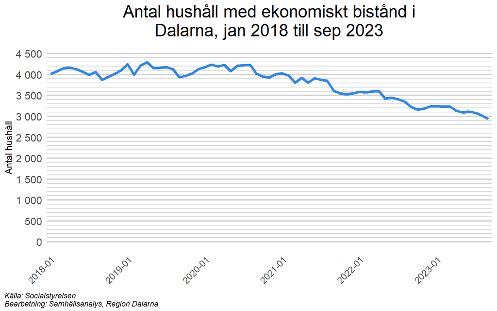

[^1]: https://en.wikipedia.org/wiki/2021%E2%80%932023_inflation_surge
[^2]: https://www.scb.se/hitta-statistik/statistik-efter-amne/finansmarknad/finansrakenskaper/finansrakenskaper-kvartal-och-ar/pong/tabell-och-diagram/arstabeller/hushallens-laneskulder-i-procent-av-justerad-disponibel-inkomst-och-av-hushallens-finansiella-tillgangar/
[^3]: https://region-dalarna.github.io/kvinnor_man_i_Dalarna/